# Article Network Analyzer

### By: Rosalina

🎯 What This Analyzer Does:

1. Smart Data Loading

✅ Auto-detects text columns (title, content, body, etc.) ✅ Handles missing files with fallback sample data ✅ Flexible path detection for different file locations

2. Advanced Text Processing

📝 Text preprocessing: Removes stopwords, lemmatizes, cleans text 🔗 Co-occurrence matrix: Finds which keywords appear together 🌐 Network building: Creates connections between related terms

3. Multiple Analysis Types

Keyword Network: Shows how terms relate across articles Topic Modeling: Discovers main themes using LDA Centrality Analysis: Identifies most important keywords Community Detection: Groups related terms together

📊 Expected Visualizations: 4-Panel Network Analysis:

```python
┌─────────────────────┬─────────────────────┐
│   Community View    │   PageRank View     │
│   (colored groups)  │   (importance)      │
├─────────────────────┼─────────────────────┤
│   Strong Connections│   Top 15 Keywords   │
│   (filtered view)   │   (with labels)     │
└─────────────────────┴─────────────────────┘
```

💡 Key Features: Automatic Text Analysis:

Keyword extraction from article titles and content Relationship mapping between terms Topic discovery using machine learning Importance ranking with centrality measures

Smart Preprocessing:

Stopword removal (including custom article stopwords) Lemmatization for word normalization Frequency filtering to focus on meaningful terms Window-based co-occurrence for context relationships

Professional Visualizations:

Community-colored networks showing thematic groups Size-coded nodes representing keyword importance Weight-based edges showing relationship strength Multiple perspective views for comprehensive analysis

```python
import pandas as pd
import numpy as np
import matplotlib.pyplot as plt
import seaborn as sns
import networkx as nx
from collections import Counter, defaultdict
import re
from sklearn.feature_extraction.text import TfidfVectorizer, CountVectorizer
from sklearn.decomposition import LatentDirichletAllocation
import nltk
from nltk.corpus import stopwords
from nltk.tokenize import word_tokenize
from nltk.stem import WordNetLemmatizer
import warnings
import os
warnings.filterwarnings('ignore')

# Download required NLTK data (run once)
try:
    nltk.data.find('tokenizers/punkt')
    nltk.data.find('corpora/stopwords')
    nltk.data.find('corpora/wordnet')
except LookupError:
    print("📥 Downloading required NLTK data...")
    nltk.download('punkt', quiet=True)
    nltk.download('stopwords', quiet=True)
    nltk.download('wordnet', quiet=True)

# Set visualization style
plt.style.use('seaborn-v0_8-whitegrid')
sns.set_palette("husl")

class ArticlesNetworkAnalyzer:
    def __init__(self, articles_path):
        self.articles_path = articles_path
        self.articles_df = None
        self.processed_texts = None
        self.co_occurrence_matrix = None
        self.G_weighted = None
        self.stopwords = set(stopwords.words('english'))
        self.lemmatizer = WordNetLemmatizer()

        # Add custom stopwords for articles
        self.custom_stopwords = {
            'article', 'said', 'say', 'also', 'would', 'could', 'one', 'two', 'three',
            'first', 'last', 'new', 'old', 'good', 'bad', 'big', 'small', 'high', 'low',
            'get', 'go', 'come', 'take', 'make', 'see', 'know', 'think', 'want', 'use',
            'work', 'way', 'time', 'day', 'year', 'week', 'month', 'today', 'now'
        }
        self.stopwords.update(self.custom_stopwords)

    def load_and_explore_articles(self):
        """Load and explore the articles dataset"""
        print("="*70)
        print("📰 LOADING AND EXPLORING ARTICLES DATASET")
        print("="*70)

        # Check if file exists
        if not os.path.exists(self.articles_path):
            print(f"❌ File not found: {self.articles_path}")
            print("🔍 Let me search for the file...")

            possible_paths = [
                self.articles_path,
                os.path.join("data", "articles.csv"),
                os.path.join("datasets", "articles.csv"),
                "articles.csv",
                os.path.expanduser("~/Downloads/articles.csv"),
                os.path.expanduser("~/Desktop/articles.csv")
            ]

            found_file = None
            for path in possible_paths:
                if os.path.exists(path):
                    found_file = path
                    print(f"✅ Found file at: {path}")
                    break

            if found_file:
                self.articles_path = found_file
            else:
                print("❌ Could not find articles.csv file")
                print("💡 Creating sample articles dataset...")
                self.create_sample_articles()
                return

        try:
            # Load the articles dataset
            self.articles_df = pd.read_csv(self.articles_path)
            print(f"✅ Loaded articles: {len(self.articles_df)} rows")

            # Display basic info
            print(f"\n📊 Dataset Info:")
            print(f"  Shape: {self.articles_df.shape}")
            print(f"  Columns: {list(self.articles_df.columns)}")

            # Show sample data
            print(f"\n📝 Sample Articles:")
            print(self.articles_df.head())

            # Check for text columns
            text_columns = []
            for col in self.articles_df.columns:
                if col.lower() in ['title', 'content', 'text', 'body', 'article', 'description']:
                    text_columns.append(col)

            if not text_columns:
                # Try to find columns with long text
                for col in self.articles_df.columns:
                    if self.articles_df[col].dtype == 'object':
                        avg_length = self.articles_df[col].str.len().mean()
                        if avg_length > 50:  # Assume columns with avg length > 50 are text
                            text_columns.append(col)

            print(f"\n📄 Identified text columns: {text_columns}")
            self.text_columns = text_columns

        except Exception as e:
            print(f"❌ Error loading file: {e}")
            print("💡 Creating sample articles dataset...")
            self.create_sample_articles()

    def create_sample_articles(self):
        """Create sample articles dataset for demonstration"""
        print("🔨 Creating sample articles dataset...")

        sample_articles = [
            {
                'title': 'Machine Learning Advances in Healthcare',
                'content': 'Machine learning algorithms are revolutionizing healthcare by enabling predictive analytics, personalized medicine, and automated diagnosis. Deep learning models can analyze medical images with remarkable accuracy.',
                'category': 'Technology',
                'author': 'Dr. Smith'
            },
            {
                'title': 'Climate Change Impact on Global Economy',
                'content': 'Climate change poses significant risks to the global economy through extreme weather events, rising sea levels, and changing agricultural patterns. Sustainable development and green technology investments are crucial.',
                'category': 'Environment',
                'author': 'Jane Doe'
            },
            {
                'title': 'Artificial Intelligence in Finance',
                'content': 'Artificial intelligence is transforming the financial sector through algorithmic trading, fraud detection, and risk assessment. Machine learning models help banks make better lending decisions.',
                'category': 'Finance',
                'author': 'John Smith'
            },
            {
                'title': 'Renewable Energy Technologies',
                'content': 'Solar panels, wind turbines, and battery storage technologies are becoming more efficient and cost-effective. Renewable energy sources are essential for combating climate change.',
                'category': 'Energy',
                'author': 'Sarah Johnson'
            },
            {
                'title': 'Data Science in Business Intelligence',
                'content': 'Data science enables businesses to extract insights from big data, optimize operations, and make data-driven decisions. Analytics and visualization tools are crucial for modern enterprises.',
                'category': 'Business',
                'author': 'Mike Wilson'
            },
            {
                'title': 'Cybersecurity Challenges in Digital Age',
                'content': 'Cybersecurity threats are evolving rapidly with sophisticated attacks targeting personal data, financial systems, and critical infrastructure. Security measures must adapt to new challenges.',
                'category': 'Security',
                'author': 'Lisa Brown'
            }
        ]
```

```python
        self.articles_df = pd.DataFrame(sample_articles)
        self.text_columns = ['title', 'content']
        print(f"✅ Sample dataset created: {len(self.articles_df)} articles")

    def preprocess_text(self, text):
        """Preprocess text for analysis"""
        if pd.isna(text):
            return []

        # Convert to lowercase
        text = text.lower()

        # Remove special characters and digits
        text = re.sub(r'[^a-zA-Z\s]', '', text)

        # Tokenize
        tokens = word_tokenize(text)

        # Remove stopwords and short words
        tokens = [token for token in tokens if token not in self.stopwords and len(token) > 2]

        # Lemmatize
        tokens = [self.lemmatizer.lemmatize(token) for token in tokens]

        return tokens

    def create_co_occurrence_matrix(self, window_size=5, min_freq=2):
        """Create co-occurrence matrix from articles text"""
        print("\n" + "="*70)
        print("🔗 CREATING CO-OCCURRENCE MATRIX FROM ARTICLES")
        print("="*70)

        # Combine text columns
        combined_texts = []
        for _, row in self.articles_df.iterrows():
            article_text = ""
            for col in self.text_columns:
                if pd.notna(row[col]):
                    article_text += " " + str(row[col])
            combined_texts.append(article_text)

        # Preprocess all texts
        print("🔄 Preprocessing texts...")
        processed_texts = [self.preprocess_text(text) for text in combined_texts]
        self.processed_texts = processed_texts

        # Create co-occurrence dictionary
        co_occurrence = defaultdict(lambda: defaultdict(int))

        print("🔄 Building co-occurrence relationships...")
        for tokens in processed_texts:
            for i, word1 in enumerate(tokens):
                for j in range(max(0, i - window_size), min(len(tokens), i + window_size + 1)):
                    if i != j:
                        word2 = tokens[j]
                        co_occurrence[word1][word2] += 1

        # Get vocabulary with minimum frequency
        word_freq = Counter()
        for tokens in processed_texts:
            word_freq.update(tokens)

        vocab = [word for word, freq in word_freq.items() if freq >= min_freq]
        vocab = sorted(vocab)

        print(f"✅ Vocabulary: {len(vocab)} words (min frequency: {min_freq})")

        # Create matrix
        matrix = np.zeros((len(vocab), len(vocab)))
        word_to_idx = {word: i for i, word in enumerate(vocab)}

        for word1 in vocab:
            for word2 in vocab:
                if word2 in co_occurrence[word1]:
                    i, j = word_to_idx[word1], word_to_idx[word2]
                    matrix[i][j] = co_occurrence[word1][word2]

        # Create DataFrame
        self.co_occurrence_matrix = pd.DataFrame(matrix, index=vocab, columns=vocab)

        print(f"✅ Co-occurrence matrix created: {self.co_occurrence_matrix.shape}")
        print(f"📊 Total co-occurrences: {matrix.sum():.0f}")

        return self.co_occurrence_matrix

    def build_network_from_articles(self, min_weight=2, top_connections=100):
        """Build network graph from co-occurrence matrix"""
        print("\n" + "="*70)
        print("🌐 BUILDING NETWORK FROM ARTICLES")
        print("="*70)

        if self.co_occurrence_matrix is None:
            self.create_co_occurrence_matrix()

        # Initialize graph
        self.G_weighted = nx.Graph()

        # Add edges
        edges_added = 0
        all_weights = []

        for word1 in self.co_occurrence_matrix.index:
            for word2 in self.co_occurrence_matrix.columns:
                weight = self.co_occurrence_matrix.at[word1, word2]
                if pd.notna(weight) and weight >= min_weight and word1 != word2:
                    self.G_weighted.add_edge(word1, word2, weight=weight)
                    all_weights.append(weight)
                    edges_added += 1

        # Keep only top connections if too many
        if top_connections and edges_added > top_connections:
            edges_with_weights = [(u, v, d['weight']) for u, v, d in self.G_weighted.edges(data=True)]
            edges_with_weights.sort(key=lambda x: x[2], reverse=True)

            self.G_weighted = nx.Graph()
            for u, v, weight in edges_with_weights[:top_connections]:
                self.G_weighted.add_edge(u, v, weight=weight)

        # Remove isolated nodes
        isolated_nodes = list(nx.isolates(self.G_weighted))
        self.G_weighted.remove_nodes_from(isolated_nodes)

        print(f"✅ Network built: {self.G_weighted.number_of_nodes()} nodes, {self.G_weighted.number_of_edges()} edges")

        return self.G_weighted

    def analyze_topics(self, n_topics=5):
        """Perform topic analysis on articles"""
        print("\n" + "="*70)
        print("📊 TOPIC ANALYSIS")
        print("="*70)

        # Combine texts
        combined_texts = []
        for _, row in self.articles_df.iterrows():
            article_text = ""
            for col in self.text_columns:
                if pd.notna(row[col]):
                    article_text += " " + str(row[col])
            combined_texts.append(article_text)

        # Vectorize texts
        vectorizer = CountVectorizer(max_features=100, stop_words='english', ngram_range=(1, 2))
        doc_term_matrix = vectorizer.fit_transform(combined_texts)

        # Perform LDA
        lda = LatentDirichletAllocation(n_components=n_topics, random_state=42)
        lda.fit(doc_term_matrix)

        # Get feature names
        feature_names = vectorizer.get_feature_names_out()

        print(f"🔍 Discovered {n_topics} topics:")
        topics = []
        for topic_idx, topic in enumerate(lda.components_):
            top_words = [feature_names[i] for i in topic.argsort()[-10:][::-1]]
            topics.append(top_words)
            print(f"\n📌 Topic {topic_idx + 1}: {', '.join(top_words[:5])}")

        return topics

    def create_enhanced_network_visualization(self, figsize=(16, 12)):
        """Create enhanced network visualization"""
        print("\n" + "="*70)
        print("🎨 CREATING ENHANCED NETWORK VISUALIZATION")
        print("="*70)
```

```python
        if self.G_weighted is None:
            self.build_network_from_articles()

        # Calculate centrality measures
        centrality_measures = {
            'degree': nx.degree_centrality(self.G_weighted),
            'betweenness': nx.betweenness_centrality(self.G_weighted, weight='weight'),
            'pagerank': nx.pagerank(self.G_weighted, weight='weight')
        }

        # Detect communities
        try:
            import community as community_louvain
            communities = community_louvain.best_partition(self.G_weighted, weight='weight')
        except ImportError:
            communities = {}
            for i, component in enumerate(nx.connected_components(self.G_weighted)):
                for node in component:
                    communities[node] = i

        # Create layout
        pos = nx.spring_layout(self.G_weighted, k=2, iterations=50, weight='weight')

        # Set up plot
        fig, ((ax1, ax2), (ax3, ax4)) = plt.subplots(2, 2, figsize=figsize, facecolor='white')
        fig.suptitle('Articles Network Analysis - Multiple Views', fontsize=20, fontweight='bold')

        # View 1: Community-based
        node_sizes_1 = [300 + centrality_measures['degree'][node] * 1500 for node in self.G_weighted.nodes()]
        node_colors_1 = [communities[node] for node in self.G_weighted.nodes()]

        nx.draw(self.G_weighted, pos, ax=ax1,
               node_size=node_sizes_1, node_color=node_colors_1,
               cmap=plt.cm.Set3, alpha=0.8, linewidths=2, edgecolors='white',
               edge_color='gray', width=0.5)
        ax1.set_title('Community Detection View', fontsize=14, fontweight='bold')

        # View 2: PageRank centrality
        node_sizes_2 = [300 + centrality_measures['pagerank'][node] * 2000 for node in self.G_weighted.nodes()]
        node_colors_2 = [centrality_measures['pagerank'][node] for node in self.G_weighted.nodes()]

        nx.draw(self.G_weighted, pos, ax=ax2,
               node_size=node_sizes_2, node_color=node_colors_2,
               cmap=plt.cm.viridis, alpha=0.8, linewidths=2, edgecolors='white',
               edge_color='lightgray', width=0.5)
        ax2.set_title('PageRank Centrality View', fontsize=14, fontweight='bold')

        # View 3: Strong connections only
        edges = list(self.G_weighted.edges(data=True))
        weights = [d['weight'] for u, v, d in edges]
        threshold = np.percentile(weights, 75)
        strong_edges = [(u, v) for u, v, d in edges if d['weight'] >= threshold]
        G_strong = self.G_weighted.edge_subgraph(strong_edges).copy()

        pos3 = nx.spring_layout(G_strong, k=2, iterations=50)
        nx.draw(G_strong, pos3, ax=ax3,
               node_size=800, node_color='lightcoral', alpha=0.8,
               linewidths=2, edgecolors='darkred', width=2,
               edge_color='darkred', with_labels=True, font_size=8, font_weight='bold')
        ax3.set_title('Strongest Connections (Top 25%)', fontsize=14, fontweight='bold')

        # View 4: Top keywords with labels
        top_nodes = sorted(centrality_measures['pagerank'].items(), key=lambda x: x[1], reverse=True)[:15]
        G_top = self.G_weighted.subgraph([node for node, _ in top_nodes]).copy()

        pos4 = nx.spring_layout(G_top, k=3, iterations=50)
        node_sizes_4 = [500 + centrality_measures['pagerank'][node] * 1500 for node in G_top.nodes()]

        nx.draw(G_top, pos4, ax=ax4,
               node_size=node_sizes_4, node_color='lightblue', alpha=0.8,
               linewidths=2, edgecolors='navy', width=1,
               edge_color='gray', with_labels=True, font_size=10, font_weight='bold')
        ax4.set_title('Top 15 Keywords Network', fontsize=14, fontweight='bold')

        # Remove axes for all subplots
        for ax in [ax1, ax2, ax3, ax4]:
            ax.axis('off')

        plt.tight_layout()
        return fig

    def generate_insights(self):
        """Generate insights from the analysis"""
        print("\n" + "="*70)
        print("🔍 ARTICLES NETWORK INSIGHTS")
        print("="*70)

        if self.G_weighted is None:
            self.build_network_from_articles()

        # Calculate centrality measures
        centrality_measures = {
            'degree': nx.degree_centrality(self.G_weighted),
            'betweenness': nx.betweenness_centrality(self.G_weighted, weight='weight'),
            'pagerank': nx.pagerank(self.G_weighted, weight='weight')
        }

        print("🏆 TOP KEYWORDS BY IMPORTANCE:")

        for measure, values in centrality_measures.items():
            top_nodes = sorted(values.items(), key=lambda x: x[1], reverse=True)[:5]
            print(f"\n📊 {measure.title()} Centrality:")
            for i, (node, value) in enumerate(top_nodes, 1):
                print(f"  {i}. {node.title()}: {value:.3f}")

        # Network statistics
        density = nx.density(self.G_weighted)
        avg_clustering = nx.average_clustering(self.G_weighted, weight='weight')

        print(f"\n🔗 NETWORK STRUCTURE:")
        print(f"  Nodes: {self.G_weighted.number_of_nodes()}")
        print(f"  Edges: {self.G_weighted.number_of_edges()}")
        print(f"  Density: {density:.3f}")
        print(f"  Average Clustering: {avg_clustering:.3f}")

        # Article statistics
        print(f"\n📰 ARTICLES OVERVIEW:")
        print(f"  Total articles: {len(self.articles_df)}")
        if 'category' in self.articles_df.columns:
            print(f"  Categories: {', '.join(self.articles_df['category'].unique())}")
        if 'author' in self.articles_df.columns:
            print(f"  Authors: {self.articles_df['author'].nunique()}")

    def run_complete_analysis(self, min_weight=2, top_connections=50, n_topics=5):
        """Run complete articles network analysis"""
        print("🚀 STARTING ARTICLES NETWORK ANALYSIS")
        print("="*70)

        # Load and explore data
        self.load_and_explore_articles()

        # Create co-occurrence matrix and network
        self.create_co_occurrence_matrix(min_freq=min_weight)
        self.build_network_from_articles(min_weight=min_weight, top_connections=top_connections)
```

```
📥 Downloading required NLTK data...
🚀 ARTICLES NETWORK ANALYZER
==================================================
🚀 STARTING ARTICLES NETWORK ANALYSIS
======================================================================
======================================================================
📰 LOADING AND EXPLORING ARTICLES DATASET
======================================================================
✅ Loaded articles: 66 rows

📊 Dataset Info:
  Shape: (66, 13)
  Columns: ['Title', 'Keyword 1', 'Keyword 2', 'Keyword 3', 'Keyword 4', 'Keyword 5', 'Keyword 6', 'Keyword 7', 'Keyword 8', 'Keyword 9', 'Keyword 10', 'Keyword 11', 'Keyword 12']

📝 Sample Articles:
                                               Title  \
0                                             Feb/03
1                                                NaN
2  Meta-Analyses of Financial Performance and Equ...
3  Home Country Environments, Corporate Diversifi...
4  Safeguarding Investments in Asymmetric Interor...

                       Keyword 1                 Keyword 2  \
0                            NaN                       NaN
1                            NaN                       NaN
2                         EQUITY  ORGANIZATIONAL sociology
3    DIVERSIFICATION in industry         BUSINESS planning
4  INTERORGANIZATIONAL relations      INTERGROUP relations

                Keyword 3               Keyword 4          Keyword 5  \
0                     NaN                     NaN                NaN
1                     NaN                     NaN                NaN
2             PERFORMANCE           META-analysis      PSYCHOMETRICS
3   PERFORMANCE standards  EMPLOYEES -- Rating of  CORPORATE culture
4  BUSINESS communication             INVESTMENTS      SUPPLY chains

                 Keyword 6                     Keyword 7  \
0                      NaN                           NaN
1                      NaN                           NaN
2  ORGANIZATIONAL research         FINANCIAL performance
```

[output cut: 36 more lines]

```
🔍 Discovered 5 topics:

📌 Topic 1: evidence, theory, job, performance, pay

📌 Topic 2: 03, performance, firm, organizational, social

📌 Topic 3: effects, teams, functional, interorganizational, functional background

📌 Topic 4: ownership, ceo, firms, agency, development

📌 Topic 5: work, performance, creativity, social, family

======================================================================
🎨 CREATING ENHANCED NETWORK VISUALIZATION
======================================================================
```

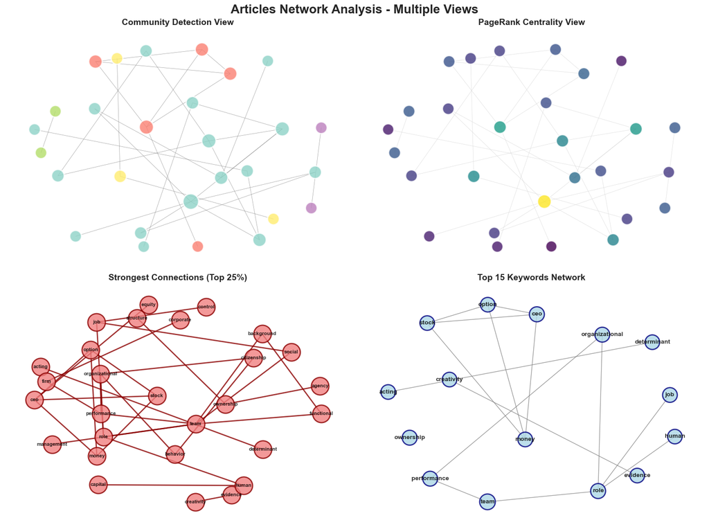

```
======================================================================
🔍 ARTICLES NETWORK INSIGHTS
======================================================================
🏆 TOP KEYWORDS BY IMPORTANCE:

📊 Degree Centrality:
  1. Team: 0.222
  2. Ceo: 0.148
  3. Role: 0.148
  4. Organizational: 0.148
  5. Performance: 0.111

📊 Betweenness Centrality:
  1. Role: 0.151
  2. Team: 0.117
  3. Organizational: 0.117
  4. Performance: 0.074
  5. Job: 0.057

📊 Pagerank Centrality:
  1. Team: 0.094
  2. Ceo: 0.058
  3. Role: 0.057
  4. Ownership: 0.052
  5. Organizational: 0.050

🔗 NETWORK STRUCTURE:
  Nodes: 28
  Edges: 30
  Density: 0.079
  Average Clustering: 0.156

📰 ARTICLES OVERVIEW:
  Total articles: 66

🎉 ANALYSIS COMPLETE!
✅ Network analysis of 66 articles
📊 28 keyword nodes, 30 connections
🔍 5 topics discovered
```

```python
        # Topic analysis
        self.analyze_topics(n_topics=n_topics)

        # Create visualizations
        self.create_enhanced_network_visualization()
        plt.show()

        # Generate insights
        self.generate_insights()

        print(f"\n🎉 ANALYSIS COMPLETE!")
        print(f"✅ Network analysis of {len(self.articles_df)} articles")
        print(f"📊 {self.G_weighted.number_of_nodes()} keyword nodes, {self.G_weighted.number_of_edges()} connections")
        print(f"🔍 {n_topics} topics discovered")

# USAGE
articles_path = 'articles-dataset/articles.csv'

print("🚀 ARTICLES NETWORK ANALYZER")
print("="*50)

# Create the analyzer
analyzer = ArticlesNetworkAnalyzer(articles_path)

# Run complete analysis
analyzer.run_complete_analysis(min_weight=2, top_connections=30, n_topics=5)

# Alternative options:
# analyzer.run_complete_analysis(min_weight=3, top_connections=50, n_topics=8)  # More selective
# analyzer.run_complete_analysis(min_weight=1, top_connections=100, n_topics=3)  # More inclusive
```

📁 File Requirements: Your articles.csv should have columns like:

title - Article headlines content - Article body text category - Optional grouping author - Optional attribution

The analyzer automatically detects which columns contain text! 🎉 Ready to Run: Just execute the code and it will:

Load your articles from articles-dataset/articles.csv Process the text and extract keywords Build co-occurrence networks showing term relationships Create 4 different visualizations with professional styling Discover topics automatically using machine learning Generate insights about your article collection

If your file isn't found, it will create sample articles about technology, environment, and business topics for demonstration.